# Variable selection for species distribution modeling: an example with the western spadefoot toad

Kevin Neal

June 12, 2015

# Introduction

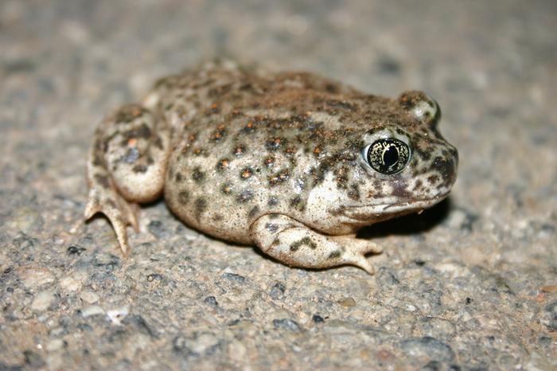

Species distribution modeling (SDM), or sometimes “ecological niche modeling,” (ENM), is a tool for predicting species distributions and for determining environmental or other correlates of a species’ presence in a given location. These models use a combination of spatial environmental layers, where each pixel has a value of some environmental parameter, and species occurrence points for its predictions. A popular program for conducting these is Maxent (Phillips et al. 2006; Phillips and Dudík 2008), which models species occupancy probabilities on a landscape using maximum entropy.

As explained by Elith and colleagues (2011), Maxent uses environmental covariate data from known presence/occurrence points and from a random sampling of background points across a landscape (“pseudoabsences”) to estimate the ratio of the covariate distribution at presence sites f1(z) to the covariate distribution of the background f(z), choosing f1(z) among possible distributions by minimizing the distance to f(z) (minimizing this distance can be thought of as minimizing the distance to a null model without any known occurrence data). The distance between the covariate distribution of the presence points and the background is the Kullback-Leibler divergence, i.e. the relative entropy of f1(z). The name for Maxent (the program) derives from the program’s maximizing the entropy of the “raw” geographic distribution of occupancy probabilities, which is equivalent to minimizing the relative entropy of the environmental covariate distribution f1(z) relative to f(z) (Phillips et al. 2006; Elith et al. 2011).

To most ecologists, these details of the Maxent “black box” are an afterthought. Indeed, that had been my situation. I began using Maxent with a tangible goal of using species distribution modeling to predict past, present, and future distributions of the western spadefoot toad, Spea hammondii. The initial motivation for doing SDM’s with Spea hammondii at all involved a peculiar discordance between evolutionary trees of the genus Spea generated from different genes. There are four *Spea* species: *hammondii*, *multiplicata*, *intermontana*, and *bombifrons*; all are found only in western North America; *hammondii* has no current range overlap with the others, while the other three do have some overlap throughout their respective ranges. In a phylogeny generated from eight nuclear genes, one sees a pattern of *S. hammondii* (SHAM hereafter) as the outgroup to the remaining three. However, using a mitochondrial DNA phylogeny, all SHAM individuals in the southern portion of their range come out as the sister group to *S. multiplicata* (SMULT hereafter). One hypothesis for why this may be is mitochondrial introgression from SMULT into only the southern population of SHAM, with the introgression failing to make its way north of the Tehachapi Mountains in central California. The problem with this hypothesis of introgression is that it requires there to have been interbreeding between SHAM and SMULT, when they are currently completely separated by the Mojave Desert (and no individuals of any *Spea* species are known from the Mojave). If introgression truly occurred, then, it must have taken place under different climatic circumstances under which the ranges overlapped. With the availability of global climate models from different points in the recent geologic past, to test the hypothesis I decided to use SDMs to predict the ranges of both species at representative climatic slices: a period of peak glaciation (Last Glacial Maximum, ~21ka), minimum glaciation (Last Interglacial, ~120ka), and an intermediate stage of glaciation (mid-Holocene, ~6ka). If distribution models under these different climatic scenarios showed expansions that led to the overlap of the two species, although it would not prove interbreeding, it would suggest that mitochondrial introgression could remain a viable hypothesis for the observed phylogenetic patterns.

In the literature where Maxent has been applied to real species, many if not most of the 4000+ publications use what have become the standard environmental covariates for modeling species distributions, known as “bioclim” layers (Beaumont et al. 2005; Booth et al. 2014). Bioclim layers are nineteen environmental variables generated from worldwide temperature and precipitation records presumed to be biologically relevant (that is, some combination of these variables determines, or helps to determine, the bounds of species range limits). These Bioclim layers are easily accessible and widely used, and the precedent of simply throwing all nineteen into the Maxent black box perpetuates the same; this in spite of the fact that many of the variables are often highly correlated with one another. Maxent has been described as robust to this sort of overparameterization through its inbuilt method for regularization, with Elith et al. (2011) noting Maxent “is unlikely to be improved – and more likely, degraded – by procedures that use other modelling methods to pre-select variables.” Even if this is the case [and my personal dealings with it actually show this to be accurate], variable selection is likely to be important when the Maxent model is used to make predictions in different regions or climates that have novel combinations of variable values outside the bounds of the input environmental parameter space. Because in my research I am using Maxent to predict occurrences in past and future climate scenarios, variable selection ought to be important for creating a more generalizable model (to say nothing of compliance with philosophical parsimony).

For this project I explored variable selection for species distribution modeling of *Spea hammondii* using both stepwise regression and mutual information. For project manageability/as a first-run dive into understanding the applications of regression and information theoretic statistics to variable selection for an SDM outside of a black box, I used generalized linear modeling (GLM) in R, rather than Maxent, to predict species occurrence probability across the landscape. I additionally used bootstrapping to examine variability in the models, and compared models using the area under the receiver operating characteristic curve (AUC).

## Materials and Methods

To obtain presence records of SHAM, I downloaded raw occurrence data from the Global Biodiversity Information Facility (GBIF). I then cleaned up this data (raw data has 200+ columns to avoid any information loss from the different field notes of researchers) to get just Longitude and Latitude. I went through a number of clean-up steps in R for quality control to remove spatially-aberrant points or entries with missing data. To avoid biasing the models’ determination of habitat suitability from the presence points, I split the study area into grid cells and subsampled a single occurrence point from each grid; this substantially reduced the number of occurrence entries (794 to 88) but is a necessary step to control for biased spatial sampling (F. Dormann et al. 2007; VanDerWal et al. 2009; Stokland et al. 2011; Barbet-Massin et al. 2012; Syfert et al. 2013; Warren et al. 2014).

I generated pseudoabsence points first by randomly sampling 1000 points from the region within 300 km of any given presence point, excluding an area of 10km around any given presence point. I then followed the same grid-sampling procedure as with the presence points to limit spatial autocorrelation. While there are arguments for both a large and small amount of pseudoabsences in SDM (VanDerWal et al. 2009), to limit computation times in later analyses I arbitrarily subsampled this down to double the number of presence points, at 176 pseudoabsences.

Using the coordinates of the presence and pseudoabsence points I then extracted values from the nineteen bioclim layers into a dataframe. For the response variable I assigned a value of “1” to presence points and “0” to pseudoabsences.

To get a sense of the correlations among the nineteen bioclim variables, in R I calculated Spearman correlation using the cor function in the corrplot package (Wei 2013), and I calculated the maximal information criteria (MIC) using the mine function in the minerva package (Filosi et al. 2014). I plotted these correlations using the corrplot function in corrplot.

I utilized mutual information (mutinformation function in package infotheo (Meyer 2014)) as suggested in Ivannikova et al (2013) to select predictors by iteratively adding predictors to the function (can think of it in a way as a forward stepwise regression, but using mutual information). The strategy is to maximize the information with the least amount of variables, with X as the predictor variables (bioclim) and Y as the response variable (i.e. presence/absence). I began the process with running mutinformation() on the whole dataframe to see which single predictor variable had the highest mutual information value with the response variable; this became the first variable selected for the model. Subsequently, I looked for the greatest information addition adding a single other predictor, one at a time, among the remaining predictors. This method precludes highly correlated variables, because the addition of a new predictor that is highly correlated with one already included will offer little to no new information, even if it is itself highly correlated with the response variable on its own—and thus the method iteratively adds variables that offer new information to the model until the information plateaus.

As a comparison, I utilized the built-in step function to implement a backwards stepwise GLM regression of the bioclim variables and presence/absence to determine the optimal combination of variables, as determined by the lowest Akaike Information Criterion (AIC) value. The stepwise regression works by calculating the AIC of models in which variables are iteratively removed, until the lowest possible AIC is achieved.

## Results and discussion

### Correlation and variable selection

Both Spearman correlation and maximal information criteria reveal strong correlations between several variable pairs within the nineteen bioclim variables, validating the concern over collinearity and model overfitting in a species distribution model of Spea hammondii in the sampled environmental space.

Using mutual information to guide variable selection, bio1 (annual mean temperature) is the first best predictor of presence or absence. The forward-stepping method settles on a GLM of presence ~ bio1 + bio2 + bio4 + bio12 + bio15 + bio16 + bio17 + bio18, with the mutual information between the predictors and response equal to 0.631. Among these variable pairs, bio1+bio17 and bio12+bio16 still appear to be highly correlated (MIC=0.710 and 0.918, respectively). Additional variables did not increase the information, and testing MI between presence and all nineteen variables also returns MI = 0.631, indicating the eight chosen variables contain as much information as all nineteen. This method of variable selection may be imperfect, however, as it fails to consider interactions between variables (which may be accomplished with conditional mutual information (Fleuret 2004), but its application is beyond the scope here). The AIC of the MI-informed GLM is 216.44.

The GLM model with the lowest AIC according to backwards stepwise regression is presence ~ bio1 + bio4 + bio9 + bio14 + bio15 + bio17 + bio18 + bio19, with AIC = 191.45. Among these variable pairs, bio1+bio17 and bio14+bio17 still appear to be highly correlated (MIC=0.710 and 0.790, respectively).

The AIC of the GLM with all nineteen variables is 207.25.

## References

Barbet-Massin, M., F. Jiguet, C. H. Albert, and W. Thuiller. 2012. Selecting pseudo-absences for species distribution models: how, where and how many? Methods Ecol. Evol. 3:327–338.  
Beaumont, L. J., L. Hughes, and M. Poulsen. 2005. Predicting species distributions: use of climatic parameters in BIOCLIM and its impact on predictions of species’ current and future distributions. Ecol. Model. 186:251–270.  
Booth, T. H., H. A. Nix, J. R. Busby, and M. F. Hutchinson. 2014. bioclim: the first species distribution modelling package, its early applications and relevance to most current MaxEnt studies. Divers. Distrib. 20:1–9.  
Elith, J., S. J. Phillips, T. Hastie, M. Dudík, Y. E. Chee, and C. J. Yates. 2011. A statistical explanation of MaxEnt for ecologists. Divers. Distrib. 17:43–57.  
F. Dormann, C., J. M. McPherson, M. B. Araújo, R. Bivand, J. Bolliger, G. Carl, R. G. Davies, A. Hirzel, W. Jetz, W. Daniel Kissling, I. Kühn, R. Ohlemüller, P. R. Peres-Neto, B. Reineking, B. Schröder, F. M. Schurr, and R. Wilson. 2007. Methods to account for spatial autocorrelation in the analysis of species distributional data: a review. Ecography 30:609–628.  
Filosi, M., R. Visintainer, D. Albanese, S. Riccadonna, G. Jurman, and C. Furlanello. 2014. minerva: minerva: Maximal Information-Based Nonparametric Exploration R package for Variable Analysis.  
Fleuret, F. 2004. Fast Binary Feature Selection with Conditional Mutual Information. J Mach Learn Res 5:1531–1555.  
Hijmans, R. J. 2012. Cross-validation of species distribution models: removing spatial sorting bias and calibration with a null model. Ecology 93:679–688.  
Hijmans, R. J., S. Phillips, and J. L. and J. Elith. 2015. dismo: Species Distribution Modeling.  
Ivannikova, E., T. Hamalainen, and K. Luostarinen. 2013. Information-theoretic approach to variable selection in predictive models applied to paper machine data. Pp. 000946–000950 in 2013 IEEE Symposium on Computers and Communications (ISCC).  
Meyer, P. E. 2014. infotheo: Information-Theoretic Measures.  
Phillips, S. J., R. P. Anderson, and R. E. Schapire. 2006. Maximum entropy modeling of species geographic distributions. Ecol. Model. 190:231–259.  
Phillips, S. J., and M. Dudík. 2008. Modeling of species distributions with Maxent: new extensions and a comprehensive evaluation. Ecography 31:161–175.  
Stokland, J. N., R. Halvorsen, and B. Støa. 2011. Species distribution modelling—Effect of design and sample size of pseudo-absence observations. Ecol. Model. 222:1800–1809.  
Syfert, M. M., M. J. Smith, and D. A. Coomes. 2013. The Effects of Sampling Bias and Model Complexity on the Predictive Performance of MaxEnt Species Distribution Models. PLoS ONE 8:e55158.  
VanDerWal, J., L. P. Shoo, C. Graham, and S. E. Williams. 2009. Selecting pseudo-absence data for presence-only distribution modeling: How far should you stray from what you know? Ecol. Model. 220:589–594.  
Warren, D. L., A. N. Wright, S. N. Seifert, and H. B. Shaffer. 2014. Incorporating model complexity and spatial sampling bias into ecological niche models of climate change risks faced by 90 California vertebrate species of concern. Divers. Distrib. 20:334–343.  
Wei, T. 2013. corrplot: Visualization of a correlation matrix.

# SUPPLEMENT: R-scripts and figures

## Loading the spadefoot toad presence and absence point data:

```r
# using spea and bioclim variables
spea.ll <- read.csv("speaLatLonBioclim.csv") # dataframe generated by extracting bioclim variable values at the latlon coordinates
spea.ll <- spea.ll[-1]
spea <- spea.ll[-c(1:2)] # creates spea which is ONLY bioclim variables, no latlon

colnames(spea.ll)[1] <- "lon" # simplifying column names
colnames(spea.ll)[2] <- "lat"
spea2 <- spea

present <- rep(1, nrow(spea))
spea2[,20] <- present
colnames(spea2)[20] <- "pres"
#summary(spea)
#corrplot(cor(spea, method="spearman"))
#pairs(spea)

### "absence" points (sampled from random background points on same grid as presence points, using chess="black" while presence points sampled from chess="white")

absent.ll <- read.csv("speaabsentLatLonBioclim.csv")
absent.ll <- absent.ll[-1]
absent <- absent.ll[,-c(1:2)] # creates dataframe of ONLY bioclim variables, no latlon
colnames(absent.ll)[1] <- "lon" # simplifying column names
colnames(absent.ll)[2] <- "lat"
absent2 <- absent

absences <- rep(0, nrow(absent))
absent2[,20] <- absences
colnames(absent2)[20] <- "pres"

allpts <- rbind(spea2, absent2)
hammy <- allpts # hammy refers to hammondii. This is the dataframe with all the presence AND absence points AND bioclim values. No latlon.
hammy.ll <- cbind(hammy, rbind(spea.ll[,c(1:2)], absent.ll[,c(1:2)])) # the dataframe INCLUDING latlon. Probably won't need for now.

spea.llonly <- spea.ll[,c(1:2)]
absent.llonly <- absent.ll[,c(1:2)]
```

**The nineteen bioclim layers are:**  
* BIO1 = Annual Mean Temperature  
* BIO2 = Mean Diurnal Range (Mean of monthly (max temp - min temp))  
* BIO3 = Isothermality (BIO2/BIO7) (* 100)  
* BIO4 = Temperature Seasonality (standard deviation *100)*  
BIO5 = Max Temperature of Warmest Month  
* BIO6 = Min Temperature of Coldest Month  
* BIO7 = Temperature Annual Range (BIO5-BIO6)  
* BIO8 = Mean Temperature of Wettest Quarter  
* BIO9 = Mean Temperature of Driest Quarter  
* BIO10 = Mean Temperature of Warmest Quarter  
* BIO11 = Mean Temperature of Coldest Quarter  
* BIO12 = Annual Precipitation  
* BIO13 = Precipitation of Wettest Month  
* BIO14 = Precipitation of Driest Month  
* BIO15 = Precipitation Seasonality (Coefficient of Variation)  
* BIO16 = Precipitation of Wettest Quarter  
* BIO17 = Precipitation of Driest Quarter  
* BIO18 = Precipitation of Warmest Quarter  
* BIO19 = Precipitation of Coldest Quarter

## Correlation plots using MIC and Spearman correlation:

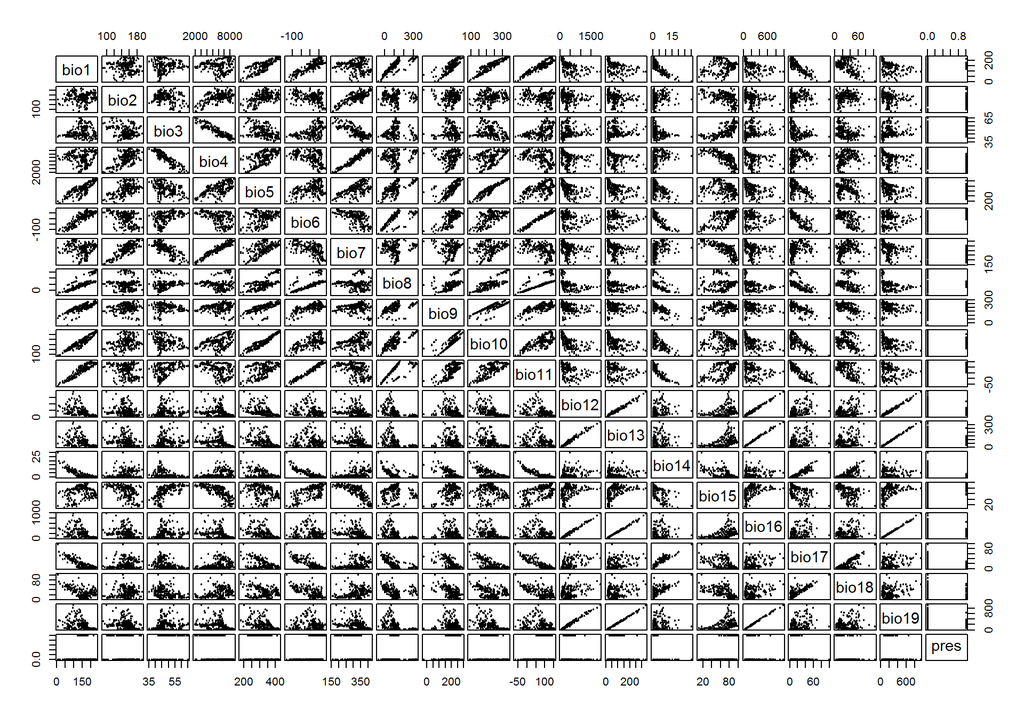

```r
pairs(hammy, cex=0.4, pch=20, gap=0.3)
```

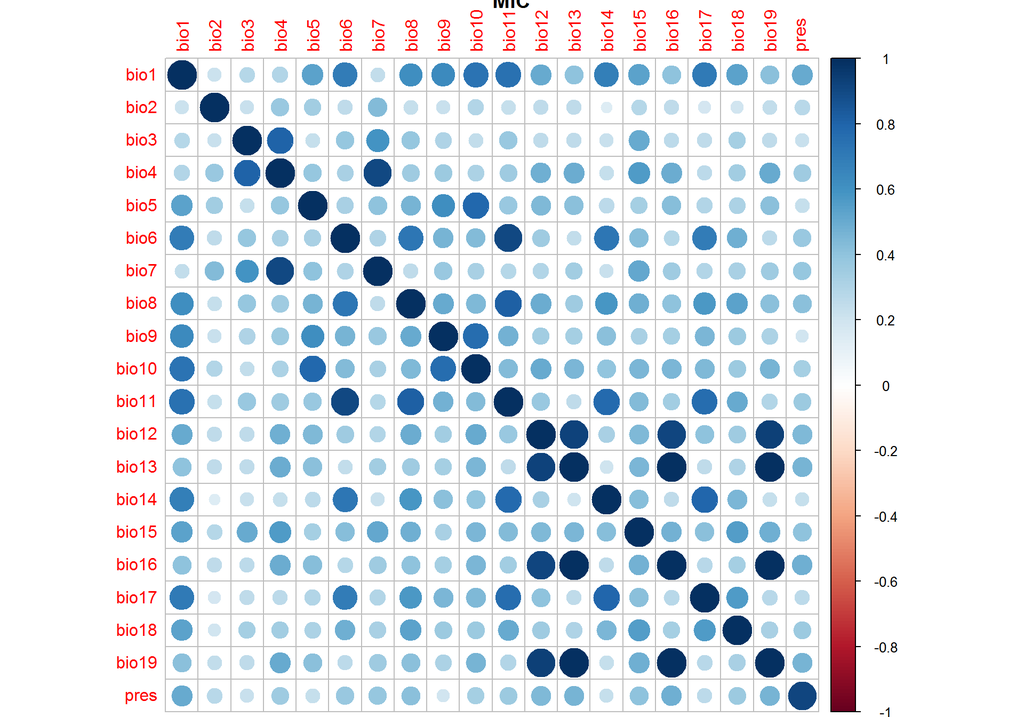

```r
par(mfrow=c(1,1))
corrplotMIC <- corrplot(mine(hammy)$MIC, main="MIC")
```

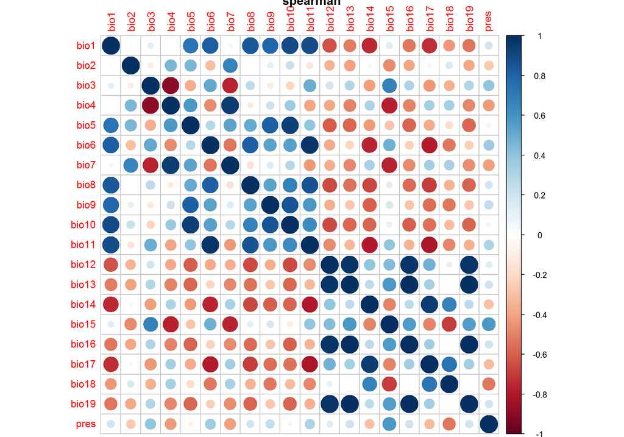

```r
corrplotSpear <- corrplot(cor(hammy, method="spearman", use="pairwise.complete.obs"), main="spearman")
```

### In the corrplots, notice the strong correlations between several variable pairs. In the optimized models, it is unlikely that both of a highly correlated pair will be included because after including one, the second will contribute little to no new information to the model.

## Mutual information variable selection (sensu Ivannikova et al.) with forward steps:

```r
# corrplot(hammy.mutinfo/max(hammy.mutinfo)) # corrplot requires values between -1 and 1. I only did this to see how its patterns compare with using the mine() function in minerva

hammy.mutinfo <- mutinformation(discretize(hammy)) # bio1 has highest mutual info, i.e. strongest correlation with presence
hammy.mutinfo[,20]

#hammybc <- hammy[,-20]
#mutinformation(discretize(hammybc), discretize(hammy[,20])) # MI = 0.631 including all variables

# mutinformation(cbind(discretize(hammy[,1]), discretize(hammy[,2])), discretize(hammy[,20], nbins=2)) # if here for example we had chosen bio2 as our X1, we add each other bioclim to it to test the information gained. The variable that leads to the highest gain is X2. Then do the same to find X3, and so on. Do this until the information goes DOWN!!! If it never goes down, then the model with all 19 variables is the best...
# this example is still using dummy-absences, though. Get "true"" pseudoabsences AND add more presences by doing smarter spatial sampling... though this is a whole can of worms...

# I can apply bootstraps to every step here... hmm then get confidence intervals on the MI of every added variable? One with highest median moves on?

# mutin1 accomplishes the same thing as just running mutinformation(discretize(hammy))
mutin1 <- rep(NA, 19)
for (i in 1:19){
  mutin1[i] <- mutinformation(discretize(hammy[,i]), discretize(hammy[,20]))
}
mutin1
#rank(mutin1) # bio1 by itself has most mutual information with presence, so bio1 becomes X1. MI = 0.2386



mutin2 <- rep(NA, 19)
for (i in 1:19){
  mutin2[i] <- mutinformation(cbind(discretize(hammy[,1]), discretize(hammy[,i])), discretize(hammy[,20]))
}

mutin2 # bio12 increases the information the most, so bio12 becomes X2. MI = 0.3576


## Then I suppose, compare the third most-informative variable (X3) determined from permuted medians to the one calculated with ALL the points.
## Here: permuted best X3 is bio2
mutin3 <- rep(NA, 19)
for(i in 1:19){
    mutin3[i] <- mutinformation(cbind(discretize(hammy[,1]), discretize(hammy[,12]), discretize(hammy[,i])), discretize(hammy[,20]))
  }
mutin
rank(mutin) # Using all the points, the best X3 is bio2; model MI(3) = 0.49495: bio1, bio12, bio2

## Let's just continue using all the points for now...

### Determining X4:
mutin4 <- rep(NA, 19)
for(i in 1:19){
    mutin4[i] <- mutinformation(cbind(discretize(hammy[,1]),
                                      discretize(hammy[,12]),
                                      discretize(hammy[,2]),
                                      discretize(hammy[,i])),
                                discretize(hammy[,20]))
  }
mutin4
rank(mutin4) # bio17 is X4; MI = 0.5748


### Determining X5:
mutin5 <- rep(NA, 19)
for(i in 1:19){
    mutin5[i] <- mutinformation(cbind(discretize(hammy[,1]),
                                      discretize(hammy[,12]),
                                      discretize(hammy[,2]),
                                      discretize(hammy[,17]),
                                      discretize(hammy[,i])),
                                discretize(hammy[,20]))
  }
mutin5
rank(mutin5) # bio4 is X5; MI = 0.6030



mutin6 <- rep(NA, 19)
for(i in 1:19){
    mutin6[i] <- mutinformation(cbind(discretize(hammy[,1]),
                                      discretize(hammy[,12]),
                                      discretize(hammy[,2]),
                                      discretize(hammy[,17]),
                                      discretize(hammy[,4]),
                                      discretize(hammy[,i])),
                                discretize(hammy[,20]))
  }
mutin6
rank(mutin6) # bio15 and bio16 are tied for X6; MI = 0.6155... maybe bootstrap to pick one??

mutin6boot <- matrix(nrow=1000, ncol=19)
for(j in 1:1000) {
  hamboot <- rbind(hammy[sample(nrow(hammy[hammy$pres==1,]), 88, replace=F),],
                   hammy[sample(nrow(hammy[hammy$pres==0,]), 88, replace=F),])
  mutin <- rep(NA, 19)
  for(i in 1:19){
    mutin[i] <- mutinformation(cbind(discretize(hamboot[,1]),
                                      discretize(hamboot[,12]),
                                      discretize(hamboot[,2]),
                                      discretize(hamboot[,17]),
                                      discretize(hamboot[,4]),
                                      discretize(hamboot[,i])),
                                discretize(hamboot[,20]))
  }
  mutin6boot[j,] <- mutin
}
mutin6CI <- apply(mutin6boot, 2, medianCI)
mutin6CI # well this didn't help... bio10 has the highest median here... could this be more informative than using all the points?...
rank(mutin6CI[1,]) # but then these results become incomparable to the other runs! fuuuuuck. So skip bootstrapping for this!! just pick one. 15 or 16. Fuck!!! I'm gonna go with 15 because Maxent put it much higher than 16...


mutin7 <- rep(NA, 19)
for(i in 1:19){
    mutin7[i] <- mutinformation(cbind(discretize(hammy[,1]),
                                      discretize(hammy[,12]),
                                      discretize(hammy[,2]),
                                      discretize(hammy[,17]),
                                      discretize(hammy[,4]),
                                      discretize(hammy[,15]),
                                      discretize(hammy[,i])),
                                discretize(hammy[,20]))
  }
mutin7
rank(mutin7) # bio16; MI = 0.626



mutin8 <- rep(NA, 19)
for(i in 1:19){
    mutin8[i] <- mutinformation(cbind(discretize(hammy[,1]),
                                      discretize(hammy[,12]),
                                      discretize(hammy[,2]),
                                      discretize(hammy[,17]),
                                      discretize(hammy[,4]),
                                      discretize(hammy[,15]),
                                      discretize(hammy[,16]),
                                      discretize(hammy[,i])),
                                discretize(hammy[,20]))
  }
mutin8
rank(mutin8) # tie: bio11 and bio18; MI = 0.6313. I'll go with bio18 because maxent suggests it is actually the most important variable



mutin9 <- rep(NA, 19)
for(i in 1:19){
    mutin9[i] <- mutinformation(cbind(discretize(hammy[,1]),
                                      discretize(hammy[,12]),
                                      discretize(hammy[,2]),
                                      discretize(hammy[,17]),
                                      discretize(hammy[,4]),
                                      discretize(hammy[,15]),
                                      discretize(hammy[,16]),
                                      discretize(hammy[,18]),
                                      discretize(hammy[,i])),
                                discretize(hammy[,20]))
  }
mutin9
rank(mutin9) # no additional information... so the current model should be the best(?)/most parsimonious, according to MI

# best model using MI: pres ~ bio1, bio2, bio4, bio12, bio15, bio16, bio17, bio18
# This model has as much information as the model with all 19 variables!
```

### Using mutual information, I identified eight predictors that have as much information as all nineteen! (MI = 0.631 eith these eight and remains at 0.631 with the addition of any other predictors)

### The chosen predictors differ from those chosen by step(), interestingly (evaluated below).

## GLM models:

```r
hammy.glm <- glm(pres ~ bio1+bio2+bio3+bio4+bio5+bio6+bio7+bio8+bio9+bio10+bio11+bio12+bio13+bio14+bio15+bio16+bio17+bio18+bio19, family=binomial(link = "logit"), data=hammy)
summary(hammy.glm)
step(hammy.glm, direction="backward")

# using step() with glm, get lowest AIC with pres ~ bio1 + bio4 + bio9 + bio14 + bio15 + bio17 + bio18 + bio19
hammy.glm.step <- glm(pres ~ bio1 + bio4 + bio9 + bio14 + bio15 + bio17 + bio18 + bio19, family=binomial(link = "logit"), data=hammy)
summary(hammy.glm.step)

# best model using MI: pres ~ bio1, bio2, bio4, bio12, bio15, bio16, bio17, bio18
# as an aside: the order you put variables into the glm with + doesn't matter...
hammy.glm.mi <- glm(pres ~ bio1 + bio12 + bio2 + bio17 + bio4 + bio15 + bio16 + bio18, family=binomial(link = "logit"), data=hammy)
summary(hammy.glm.mi)

# are there still highly correlated variables in the two reduced models? Yes!
# mine(hammy[,c(1,2,4,12,15,16,17,18)])$MIC # yes: bio1+bio17 (MIC=0.710); bio12+bio16 (MIC=0.918). Try the MI model without bio16
# mine(hammy[,c(1,4,9,14,15,17,18,19)])$MIC # yes: bio1+bio17 again; bio14+bio17 (MIC=0.790). Try the step model without bio17

# summary(glm(pres ~ bio1 + bio4 + bio9 + bio14 + bio15 + bio18 + bio19, family=binomial(link = "logit"), data=hammy)) # AIC=194.2, so it performs worse than the model that includes bio17
# summary(glm(pres ~ bio1 + bio12 + bio2 + bio17 + bio4 + bio15 + bio18, family=binomial(link = "logit"), data=hammy)) # AIC=214.78. Better! (compare to 216.44)
```

## Bootstrap functions:

### These functions bootstrap resample from the presence points and from the absence points separately (so each iteration keeps the same number of presence and absence points), and the model is re-run with the resampled datapoints. The output is the map of the median probability of all bootstrapped predictions:

```r
## bootstrapped model

bootPredict <- function(rasterbrick, model, present=spea2, absent=absent2, reps=10){ # will use spea2 and absent2
  bootpreds <- replicate(reps, {
    pp <- sample(nrow(present), replace=T)
    aa <- sample(nrow(absent), replace=T)
    bootpres <- present[pp,]
    bootabsent <- absent[aa,]
    bootallpts <- rbind(bootpres, bootabsent) # combines bootstrapped present and absence points together into one dataframe
    newmodel <- update(model, data=bootallpts)
    newpredict <- predict(rasterbrick, newmodel, type="response")

  })
  medianpred <- calc(brick(bootpreds), fun=median)
  madpred <- calc(brick(bootpreds), fun=mad)
  #confintpred <- calc(brick(bootpreds), fun=quantile, probs=c(0.025, 0.975))
  invisible(stack(medianpred, madpred))
}

# bootstrapped NHST
bootPredict.nh <- function(rasterbrick, model, locs=hammy, reps=10){ # will use spea2 and absent2
  bootpreds.nh <- replicate(reps, {
    bootallpts <- apply(locs, 2, sample, replace=F) # shuffles data within columns for doing NHST
    bootallpts <- data.frame(bootallpts)
    #colnames(bootallpts) <- colnames(locs)
    newmodel <- update(model, data=bootallpts)
    newpredict <- predict(rasterbrick, newmodel, type="response")

  })
  medianpred.nh <- calc(brick(bootpreds.nh), fun=median)
  madpred.nh <- calc(brick(bootpreds.nh), fun=mad)
  #confintpred <- calc(brick(bootpreds), fun=quantile, probs=c(0.025, 0.975))
  invisible(stack(medianpred.nh, madpred.nh))
}
```

## Model predictions:

### the package “raster” allows for explicit spatial prediction using the values in the variable rasters/maps

```r
# ?predict (use it as implemented in raster package, not dismo)
# bootstrap the predictions and plot the median

bclimRaster <- brick("C:/Users/Kevin/Google Drive/UCLA Courses or Lab meetings etc/EEB 234/Final Project files/bioclim2.5/ShamnarrowBC_2.5.grd") # this contains the raster maps of all 19 climate variables

bclimRaster.mi <- bclimRaster[[c(1,2,4,12,15,16,17,18)]] #bio1, bio2, bio4, bio12, bio15, bio16, bio17, bio18
bclimRaster.glm.step <- bclimRaster[[c(1,4,9,14,15,17,18,19)]] #bio1 + bio4 + bio9 + bio14 + bio15 + bio17 + bio18 + bio19

hammyPredict.glm.step <- predict(bclimRaster.glm.step, hammy.glm.step, type="response") # type="response" gives probabilities on logit scale using the response variable, i.e. presence/absence
hammyPredict.mi <- predict(bclimRaster.mi, hammy.glm.mi, type="response")
hammyPredict.full <- predict(bclimRaster, hammy.glm, type="response")


# bootstrap the models and take the median over all predictions. Print MAD as well.
hammyPredict.full.boot <- bootPredict(bclimRaster, hammy.glm, reps=100)
hammyPredict.full.nh <- bootPredict.nh(bclimRaster, hammy.glm, reps=100)

hammyPredict.glm.step.boot <- bootPredict(bclimRaster.glm.step, hammy.glm.step, reps=100)
hammyPredict.glm.step.nh <- bootPredict.nh(bclimRaster.glm.step, hammy.glm.step, reps=100)

hammyPredict.mi.boot <- bootPredict(bclimRaster.mi, hammy.glm.mi, reps=100)
hammyPredict.mi.nh <- bootPredict.nh(bclimRaster.mi, hammy.glm.mi, reps=100)
```

## The following maps show **probability of occurrence** projected across the study area. Because absences/pseudoabsences were not sampled from the entire study area, the model often stumbles in areas of novel climate (see e.g. lower right in all maps).

## GLM model with all 19 predictors:

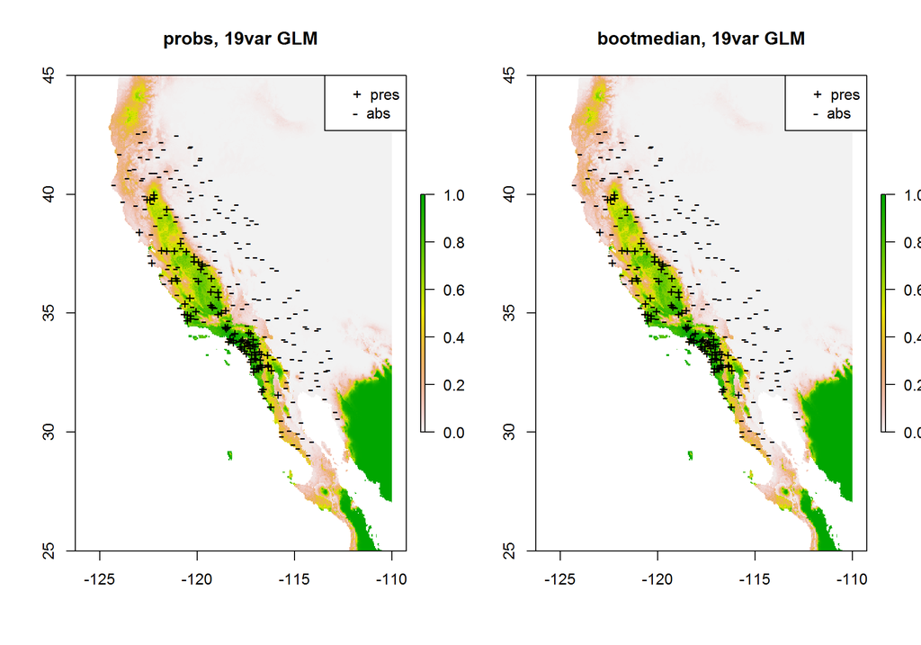

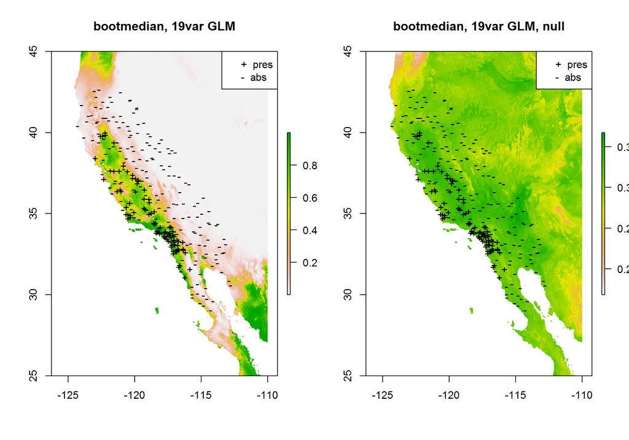

## GLM model with stepwise-determined predictors:

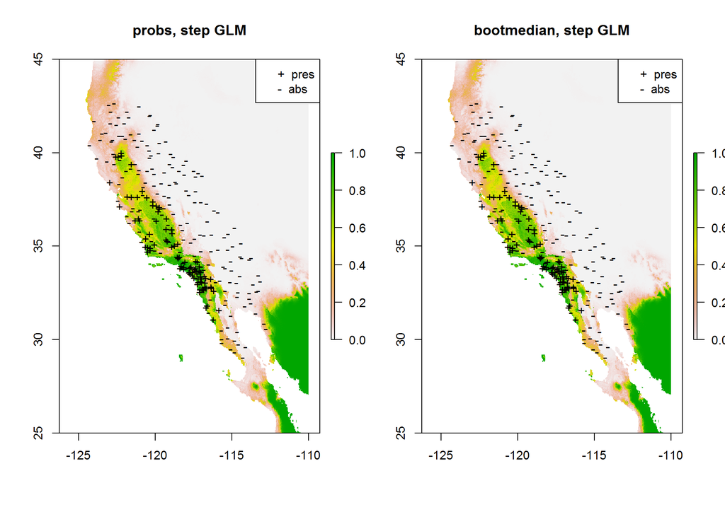

[figure not shown]

## GLM model with MI-selected predictors:

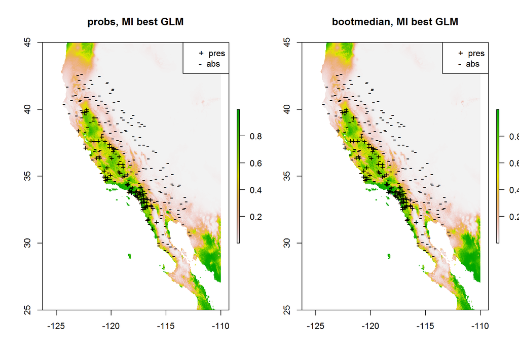

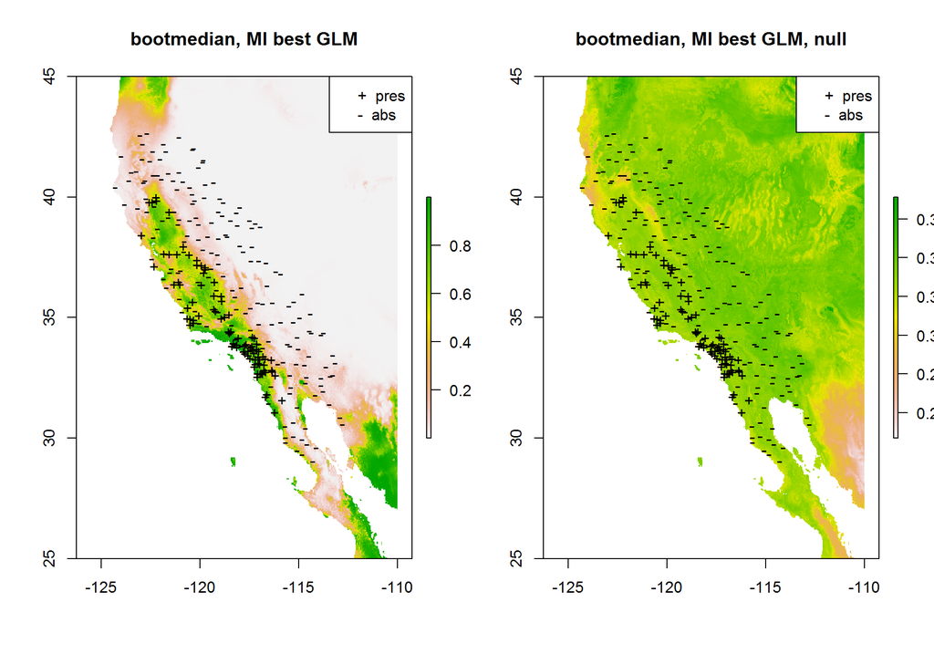

## Model probabilities of occurrence at the data used to generate the model itself. Index 1-88 are true presences (actual prob=1) and 89+ are pseudoabsences (actual prob=0):

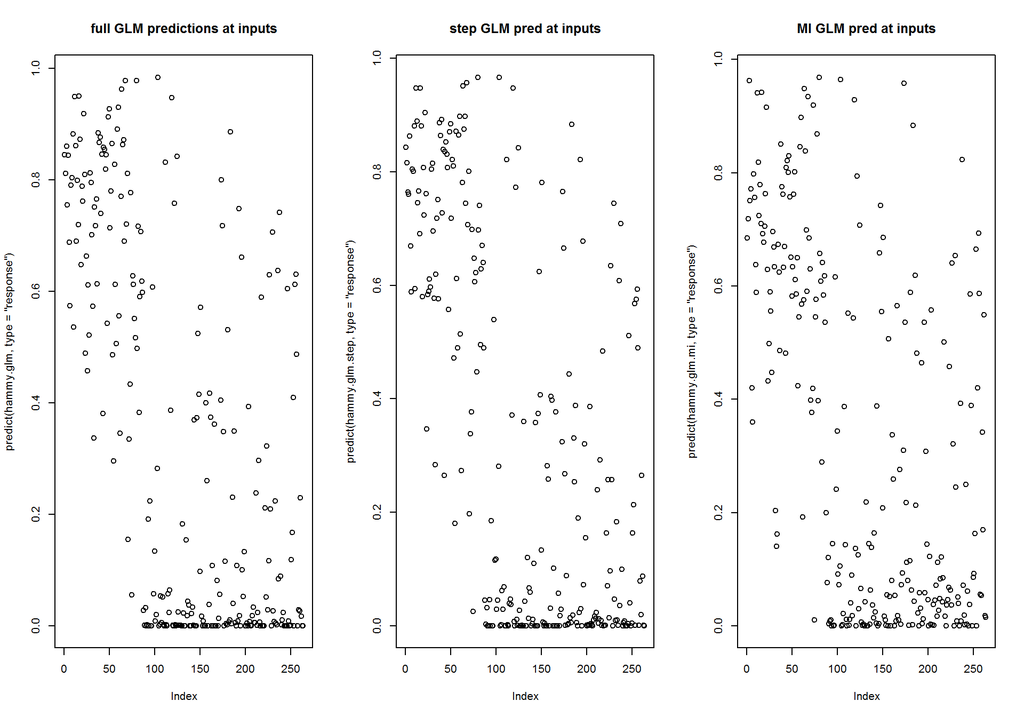

## Area under ROC curve for all three models:

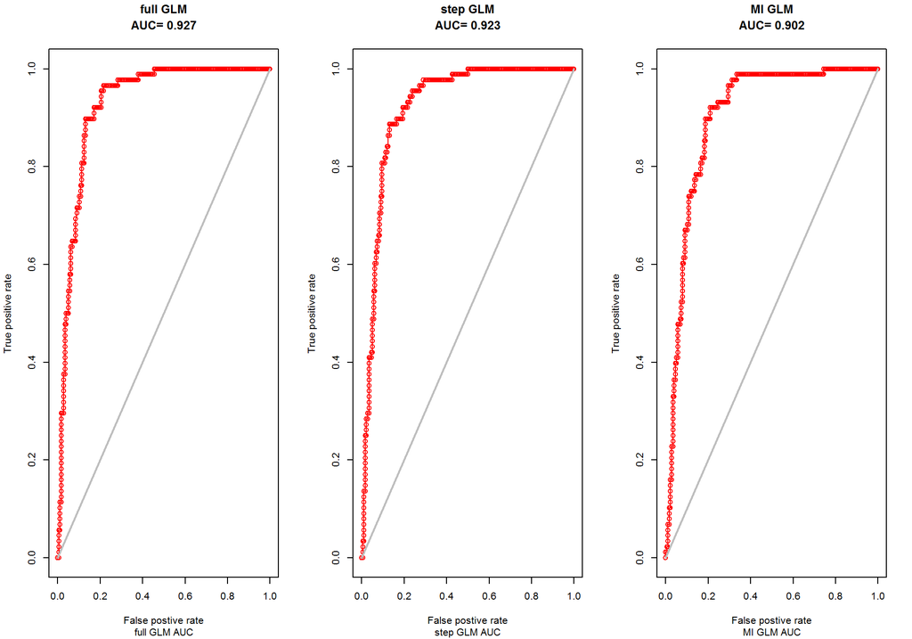

### Receiver operating characteristic curves of the three models examined. The area under these curves is assumed to be a measure of model performance, with higher AUC indicating a better model. AUC are only comparable across models using same presence and absence points and the same areal extent. With the highest AUC of 0.927, the GLM model with all 19 bioclim variables performs the best, though this may come at a cost of generalizability to novel climate spaces.